# Regression & Correlation Methods

## Environment Health, Pediatrics

### Problem # 1 (10 pts)

LD72 and LD73 are variable names for the actual blood-levels in 1972 and 1973, respectively. Let

- $ρ2$ = correlation coefficient between MAXFWT and LD72, and
- $ρ3$ = correlation coefficient between MAXFWT and LD73.

Perform a hypothesis test to statistically compare $ρ2$ and $ρ3$. Conduct all 4 steps in the hypothesis test. Make sure to report the $p$-value and a conclusion in the context of the problem.

$H0:ρ2=ρ3$

$H1:ρ2≠ρ3$

To test the hypothesis, we need to calculate the sample correlation coefficient for $ρ2$ and $ρ3$ (-0.097,-0.120)

The z transformation is then used to perform the hypothesis test by transforming the data into an approximately normally distributed scale
$$Z=12ln(1+p1−p)$$

since our $λ>0$ we find p using $2×[1−ϕλ]$

we get a p-value of $0.8>0.05$ and suggest that we do not have enough evidence to reject $H0$ and there is some association between $ρ2$ and $ρ3$.

```r
library(readr)
lead_data <- read_csv("D:/Documents/BioStatistics/LEAD.DAT.txt",show_col_types = FALSE)

##finding correlation Coefficient
lead72_cor<-cor(lead_data$`'ld72'`,lead_data$`'maxfwt'`)
lead73_cor<-cor(lead_data$`'ld73'`,lead_data$`'maxfwt'`)

#z transformation
z_73 <- 0.5 * log((1 + lead73_cor) / (1 - lead73_cor));z_73
```

```
[1] -0.1199755
```

```r
z_72 <- 0.5 * log((1 + lead72_cor) / (1 - lead72_cor));z_72
```

```
[1] -0.09730957
```

```r
#test statistic
lambda= (z_72-z_73)*sqrt(nrow(lead_data)-3);lambda
```

```
[1] 0.2493256
```

```r
#p-value
2 * (1-(pnorm(lambda)))
```

```
[1] 0.8031089
```

## Pulmonary Disease

The Data Set FEV.DAT contains pulmonary function measures on 654 children ages 3-19 seen in East Boston, MA as part of Childhood Respiratory Disease (CRD) Study. The dataset contains data on age, sex, height (inches), FEV=volume (liters) of air expelled in 1 second, and smoking status.

### Problem #2 (11.114 in text) (10 pts)

We first ran a regression of FEV on smoking shown below.

```
Call:
lm(formula = FEV ~ Smoke + Sex, data = fev.df)

Residuals:
     Min       1Q   Median       3Q      Max
-1.95758 -0.63880 -0.03123  0.52159  3.03942

Coefficients:
            Estimate Std. Error t value Pr(>|t|)
(Intercept)  2.35788    0.04774  49.394  < 2e-16 ***
Smoke1       0.76070    0.10726   7.092 3.45e-12 ***
Sex1         0.39571    0.06420   6.163 1.25e-09 ***
---
Signif. codes:  0 '***' 0.001 '**' 0.01 '*' 0.05 '.' 0.1 ' ' 1

Residual standard error: 0.8183 on 651 degrees of freedom
Multiple R-squared:  0.112, Adjusted R-squared:  0.1093
F-statistic: 41.07 on 2 and 651 DF,  p-value: < 2.2e-16
```

Estimate the average difference in FEV between smokers and non-smokers accounting for gender.

Does above estimate suggest that our common sense belief that smokers have lower pulmonary function than nonsmokers? Why or why not?

Based on the model output we can see that the “smoke1”(smokers) estimated coefficient is 0.76. This represents the mean difference in FEV between the smoking groups regardless of sex. This seems to suggest that smokers have a 0.76 unit higher lung function non-smokers which goes against common belief that smoking damages the lungs

### Problem #3 (11.115 in text) (10 pts)

It is well-known that age, height, and sex are important predictors of pulmonary function. Hence, we ran the regression model below.

```r
#fit the model
fev.mod2 <- lm(FEV~Age + Hgt + Sex + Smoke,data=fev.df)
summary(fev.mod2)
```

```
Call:
lm(formula = FEV ~ Age + Hgt + Sex + Smoke, data = fev.df)

Residuals:
     Min       1Q   Median       3Q      Max
-1.37656 -0.25033  0.00894  0.25588  1.92047

Coefficients:
             Estimate Std. Error t value Pr(>|t|)
(Intercept) -4.456974   0.222839 -20.001  < 2e-16 ***
Age          0.065509   0.009489   6.904 1.21e-11 ***
Hgt          0.104199   0.004758  21.901  < 2e-16 ***
Sex1         0.157103   0.033207   4.731 2.74e-06 ***
Smoke1      -0.087246   0.059254  -1.472    0.141
---
Signif. codes:  0 '***' 0.001 '**' 0.01 '*' 0.05 '.' 0.1 ' ' 1

Residual standard error: 0.4122 on 649 degrees of freedom
Multiple R-squared:  0.7754,    Adjusted R-squared:  0.774
F-statistic:   560 on 4 and 649 DF,  p-value: < 2.2e-16
```

How does the regression coefficient for this model for smoking differ from the regression coefficient from the linear model in the previous question?

Estimate the average difference between FEVs of a male non-smoker and a female smoker.

In the previous model there was a slight positive correlation coefficient of 0.76 suggesting that smokers have a better lung function however in the newer model that accounts for other variables, smoking has a $−0.08$ coefficient which suggests that smokers has a lower FEV than non-smokers.

the difference between a male non-smoker and female smoker is: Male non-smoker contributes only one coefficient from the model $=0.157103$ and Female smoker only constitutes the “Smoke 1” coefficient from the model:$−0.087246$ so the estimated FEV difference is approx 0.244.
$$0.157103−(−0.087246)=0.157103+0.087246=0.244349$$
This suggests that male non-smokers have a slightly better FEV than a female smoker.

## Nutrition

The assessment of diet is an important exposure for many disease outcomes. However, there is often a lot of imprecision in dietary recall. In one study, 70- to 79-year-old women were asked to recall the preschool diet of their children (when aged 2-4) using a food frequency questionnaire (FFQ). A unique aspect of the study is that simultaneous diet record (DR) data exist on the same children recorded in real time by their mothers when they were ages 2-4 and their mothers were 20 to 40 years old. The data shown below were available on average servings of margarine per week.

| ID | FFQ | DR |
| --- | --- | --- |
| 340 | 7 | 0 |
| 399 | 7 | 0.5 |
| 466 | 0 | 0 |
| 502 | 0 | 0 |
| 541 | 0 | 0 |
| 554 | 7 | 2.5 |
| 558 | 7 | 3 |
| 605 | 7 | 0.5 |
| 611 | 21 | 3.7 |
| 618 | 0 | 2.5 |
| 653 | 21 | 4.1 |
| 707 | 7 | 8.5 |

The Pearson correlation between intake from the two recording methods was 0.448.

### Problem #4 (11.120 in text) (10 pts)

The distribution of dietary intake for individual food items is often not normally distributed. An alternative measure of correlation between the FFQ and DR that does not depend on the assumption of normality is the Spearman rank correlation ($rs$). For the margarine data, $rs=0.679$.

Test the hypothesis that the Spearman rank correlation is significantly different from 0. Conduct all 4 steps of the hypothesis test. Make sure to report the two-sided $p$-value and a conclusion in the context of the problem.

Step 1: $H0:ρs=0$ vs $H1:ρs≠0$

Step 2 find the test statistics
$$t=rsn−21−rs2=2.925$$

Step 3: given that our t-value is > 0, our p-value is $2⋅P(t_10>t)$

this gives us p-value of $0.015<0.05$ therefore we can say there is sufficient evidence to suggest that there is a rank correlation between the FFQ and the DR scores and reject $H0$.

```r
r_s<-0.679
n<- 12

#t-score
t<- r_s * (sqrt(  (n-2)/(1-r_s^2) ))

#p-value
pval<- 2* (1-pt(t,df=n-2));pval
```

```
[1] 0.015176
```

## Problem #5 Lead Exposure problem (20 pts)

Using a regression to compare the mean finger-wrist tapping score (MAXFWT) between children exposed to lead and control children in the LEAD.DAT dataset

Let’s begin by reading in the data and cleaning up the column names.

```r
library(readr)
lead.df <- read_csv("D:/Documents/BioStatistics/LEAD.DAT.txt",show_col_types = FALSE)

#adjust column names
names(lead.df) <- gsub("X.", "", names(lead.df))
names(lead.df) <- gsub("['\"]", "", names(lead.df))
names(lead.df) <- gsub("_2pla", "2pla", names(lead.df))
```

In reading the documentation of the dataset, we see that missing values for the variable `maxfwt` are coded as 99. We need to remove these from the data.

```r
#remove missing values
lead.df2 <- subset(lead.df, maxfwt != 99)
```

Before running the regression model, we need to add a dummy variable to the dataset to denote group membership. A dummy variable is a binary variable used to represent a categorical variable in two categories (say A and B). We will represent group membership by the dummy variable `exposed` defined by:

- `exposed` = 1, if the child is in the exposed group
- `exposed` = 0, if the child is in the control group

```r
#dummy group variable
#Group==1 -> control
#Group==2 -> exposed

lead.df2$exposed <- as.factor(ifelse(lead.df2$Group==1, 0,1))
```

Run a simple regression model to compare the mean MAXFWT between exposed and control children.

$$MAXFWT=α+β⋅exposed+ϵ$$

```r
slr.mod <- lm(maxfwt~exposed,data=lead.df2)
summary(slr.mod)
```

```
Call:
lm(formula = maxfwt ~ exposed, data = lead.df2)

Residuals:
    Min      1Q  Median      3Q     Max
-41.438  -5.933   0.562   7.067  35.571

Coefficients:
            Estimate Std. Error t value Pr(>|t|)
(Intercept)   54.438      1.557  34.972  < 2e-16 ***
exposed1      -7.009      2.618  -2.677  0.00872 **
---
Signif. codes:  0 '***' 0.001 '**' 0.01 '*' 0.05 '.' 0.1 ' ' 1

Residual standard error: 12.45 on 97 degrees of freedom
Multiple R-squared:  0.06881,   Adjusted R-squared:  0.05921
F-statistic: 7.168 on 1 and 97 DF,  p-value: 0.008718
```

The value of the intercept is 54.438 and this indicates that the average MAXFWT will be that value given they are not exposed .

the slope is indicated by the correlation coefficient estimaate for the “exposed1” which is -7.009.

One issue with the neurologic-function data in children is that they are often strongly related to age and in some cases gender as well. Even slight age differences between the exposed and control groups could explain differences between the groups in neurologic function. We wish to determine whether MAXFWT is related to age and/or gender.

Run a multiple regression model of MAXFWT on the predictor variables age and sex where age is in years and sex is coded as 1 if male and 2 if female.

$$MAXFWT=α+β1⋅age+β2⋅sex+ϵ$$

### Problem 4: List the values of the parameter estimates, $α^$, $β^1$, and $β^2$.

```r
mult.mod1 <- lm(maxfwt ~ ageyrs+sex,data=lead.df2)
summary(mult.mod1)
```

```
Call:
lm(formula = maxfwt ~ ageyrs + sex, data = lead.df2)

Residuals:
    Min      1Q  Median      3Q     Max
-34.383  -4.646   1.352   6.173  32.511

Coefficients:
            Estimate Std. Error t value Pr(>|t|)
(Intercept)  25.8120     4.1142   6.274 1.01e-08 ***
ageyrs        2.8083     0.3362   8.352 5.08e-13 ***
sex          -1.5244     2.0573  -0.741    0.461
---
Signif. codes:  0 '***' 0.001 '**' 0.01 '*' 0.05 '.' 0.1 ' ' 1

Residual standard error: 9.846 on 96 degrees of freedom
Multiple R-squared:  0.4238,    Adjusted R-squared:  0.4118
F-statistic: 35.31 on 2 and 96 DF,  p-value: 3.207e-12
```

The partial residual plot shows that a regression line with a positive slope and this shows that age is positively related to MAXFWT, as the age increases so does the values for MAXFWT.

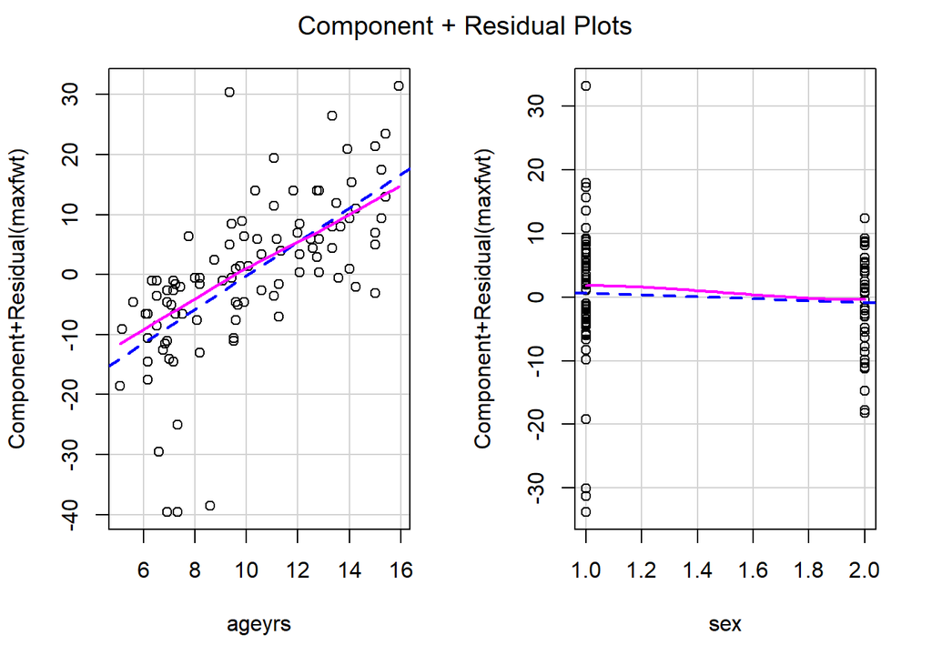

```r
crPlots(mult.mod1)
```

Compute the partial correlation between MAXFWT and age, after controlling for sex.

```r
#partial correlation
mod1 <- lm(ageyrs~sex,data=lead.df2)
resid.x <- resid(mod1)

mod2 <- lm(maxfwt~sex,data=lead.df2)
resid.y <- resid(mod2)
cor(resid.x,resid.y)
```

```
[1] 0.6487248
```

Compute the multiple correlation between MAXFWT and the predictors age and sex.

```r
#multiple correlation
sqrt(0.4238)
```

```
[1] 0.6509992
```

From the simple linear regression model relating MAXFWT to exposure status, you should have found that MAXFWT significantly differs between the exposed and control groups. Thus, it is essential to control for the exposure variable in our multiple regression model as well.

Run a multiple regression model of MAXFWT on the predictor variables age, sex, and exposure status, where age is in years, sex is coded as 1 if male and 2 if female, and exposure is a factor variable coded as 0 if the child is in the control group and 1 if the child is in the exposure group.

$$MAXFWT=α+β1⋅exposed+β2⋅age+β3⋅sex+ϵ$$

The estimated mean difference between the two exposed groups is -4.89 which suggests that the exposed group has an average -4.89 lower MAXFWT score than the control group. the the p-value is $0.0184<0.05$ which indicates that this difference is statistically significant.

```r
mult.mod2 <- lm(maxfwt ~ exposed + ageyrs+sex,data=lead.df2)
summary(mult.mod2)
```

```
Call:
lm(formula = maxfwt ~ exposed + ageyrs + sex, data = lead.df2)

Residuals:
    Min      1Q  Median      3Q     Max
-33.914  -4.155   0.998   5.567  35.552

Coefficients:
            Estimate Std. Error t value Pr(>|t|)
(Intercept)  28.6809     4.1903   6.845 7.48e-10 ***
exposed1     -4.8893     2.0383  -2.399   0.0184 *
ageyrs        2.7114     0.3307   8.199 1.14e-12 ***
sex          -1.6413     2.0087  -0.817   0.4159
---
Signif. codes:  0 '***' 0.001 '**' 0.01 '*' 0.05 '.' 0.1 ' ' 1

Residual standard error: 9.611 on 95 degrees of freedom
Multiple R-squared:  0.4567,    Adjusted R-squared:  0.4396
F-statistic: 26.62 on 3 and 95 DF,  p-value: 1.387e-12
```